# R-INLA Tutorial

GEOMED 2019 Conference - August 27, 2019

Marta Blangiardo - Imperial College

Michela Cameletti - University of Bergamo

## 1. Data description

We consider data about the number of suicides in 33 boroughs of London (2012-2014) ([datasourcelink](https://data.london.gov.uk/dataset/suicide-mortality-rates-borough)). The file **LondonSuicides.csv** contains data about the following variables: the number of suicides (`y`), the number of expected cases of suicides (`E`) and the value of the social deprivation index (`x1`).

We first import and explore the data.

```r
#mydir = "/Users/michelacameletti/Dropbox/INLA - course/Glasgow 2019/Tutorial/"
mydir = "/Users/marta/Dropbox/Teaching/INLA/Glasgow 2019/Tutorial/"
setwd(mydir)
LondonSuicides = read.csv("LondonSuicides.csv",sep=";",header=T)

dim(LondonSuicides)
```

```
## [1] 33  6
```

```r
head(LondonSuicides)
```

```
##    GSS_CODE                 NAME  y    E       SMR    x1
## 1 E09000001       City of London  4  1.5 2.6948476 12.84
## 2 E09000002 Barking and Dagenham 34 37.5 0.9077779 34.49
## 3 E09000003               Barnet 68 71.6 0.9497217 21.16
## 4 E09000004               Bexley 57 46.6 1.2227848 16.21
## 5 E09000005                Brent 64 62.5 1.0235148 29.22
## 6 E09000006              Bromley 72 62.2 1.1577239 14.36
```

```r
str(LondonSuicides)
```

```
## 'data.frame':    33 obs. of  6 variables:
##  $ GSS_CODE: Factor w/ 33 levels "E09000001","E09000002",..: 1 2 3 4 5 6 7 8 9 10 ...
##  $ NAME    : Factor w/ 33 levels "Barking and Dagenham",..: 7 1 2 3 4 5 6 8 9 10 ...
##  $ y       : int  4 34 68 57 64 72 53 83 48 50 ...
##  $ E       : num  1.5 37.5 71.6 46.6 62.5 62.2 44.1 73.1 68 62.9 ...
##  $ SMR     : num  2.695 0.908 0.95 1.223 1.024 ...
##  $ x1      : num  12.8 34.5 21.2 16.2 29.2 ...
```

```r
range(LondonSuicides$y)
```

```
## [1]  4 83
```

```r
mean(LondonSuicides$y)
```

```
## [1] 49.78788
```

```r
var(LondonSuicides$y)
```

```
## [1] 275.1723
```

```r
library(rgdal)
london.shp = readOGR(paste0(mydir,"London_Borough.shp"))
head(london.shp@data)
```

```
##                   NAME  GSS_CODE  HECTARES NONLD_AREA ONS_INNER SUB_2009 SUB_2006
## 0 Kingston upon Thames E09000021  3726.117      0.000         F     <NA>     <NA>
## 1              Croydon E09000008  8649.441      0.000         F     <NA>     <NA>
## 2              Bromley E09000006 15013.487      0.000         F     <NA>     <NA>
## 3             Hounslow E09000018  5658.541     60.755         F     <NA>     <NA>
## 4               Ealing E09000009  5554.428      0.000         F     <NA>     <NA>
## 5             Havering E09000016 11445.735    210.763         F     <NA>     <NA>
```

```r
dim(london.shp@data)
```

```
## [1] 33  7
```

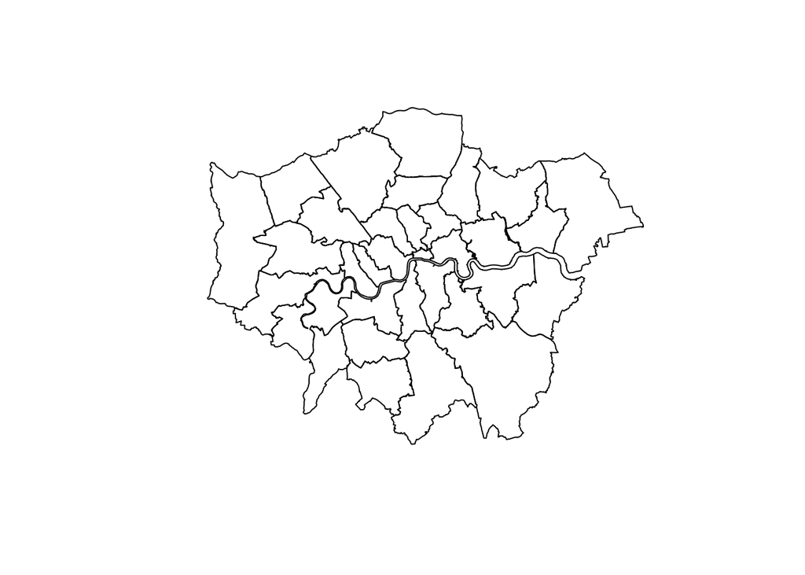

```r
plot(london.shp)
```

It is possible to plot the name of each borough (`NAME`) by placing it in the centroid of each area whose coordinate can be extracted with the `coordinates` function.

```r
head(coordinates(london.shp))
```

```
##       [,1]     [,2]
## 0 519297.6 166820.0
## 1 533290.2 163541.2
## 2 542895.5 165655.5
## 3 513515.5 175643.2
## 4 515887.9 181715.5
## 5 554049.0 187392.0
```

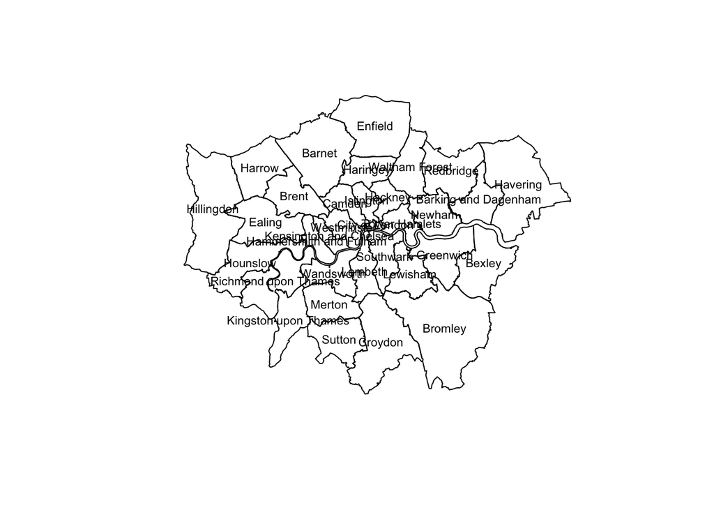

```r
plot(london.shp)
text(coordinates(london.shp)[,1],
     coordinates(london.shp)[,2],
     london.shp@data$NAME, cex=0.7)
```

Once a variabile is available in the shapefile data table it is very easy to plot it. See for example the following code for obtaining the map of the `HECTARES` variable by using the `spplot` function.

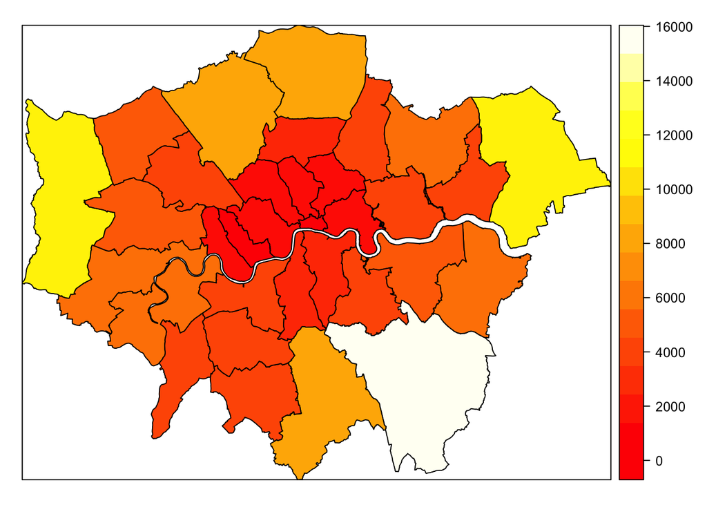

```r
library(sp)
spplot(london.shp,"HECTARES", col.regions = heat.colors(50))
```

### 1.1 Adjacency matrix creation

For implementing the spatial model we will later need the adjacency matrix (see page 40-43 of the lecture slides). The function `poly2nb` creates a binary adjacency matrix, so that two regions are neighbours only if they share at least one point in common boundary (i.e., queen adjacency).

```r
library(spdep)
london.adj = poly2nb(london.shp,queen = T)
summary(london.adj)
```

```
## Neighbour list object:
## Number of regions: 33
## Number of nonzero links: 136
## Percentage nonzero weights: 12.48852
## Average number of links: 4.121212
## Link number distribution:
##
##  2  3  4  5  6  7
##  2 10  9  7  4  1
## 2 least connected regions:
## 5 14 with 2 links
## 1 most connected region:
## 8 with 7 links
```

The following code can be used to plot the neighbourhood structure.

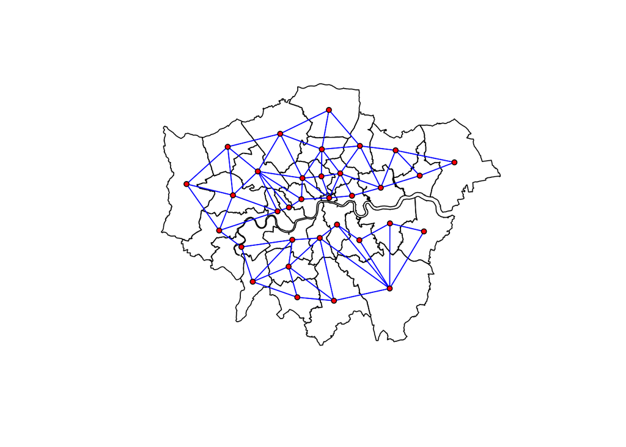

```r
plot(london.shp)
plot(london.adj, coordinates(london.shp),
     pch = ".", add = TRUE, col=4)
points(coordinates(london.shp)[,1],coordinates(london.shp)[,2],bg="red", pch=21, cex=0.75)
```

It can be seen that due the river some areas are not connected. To avoid this artefact we use the `snap` argument (boundary points less than snap distance apart are considered to indicate contiguity; see link).

```r
london.adj = poly2nb(london.shp,snap=700, queen = T)
summary(london.adj)
```

```
## Neighbour list object:
## Number of regions: 33
## Number of nonzero links: 176
## Percentage nonzero weights: 16.16162
## Average number of links: 5.333333
## Link number distribution:
##
## 3 4 5 6 7 8
## 4 6 7 9 5 2
## 4 least connected regions:
## 5 6 15 18 with 3 links
## 2 most connected regions:
## 10 24 with 8 links
```

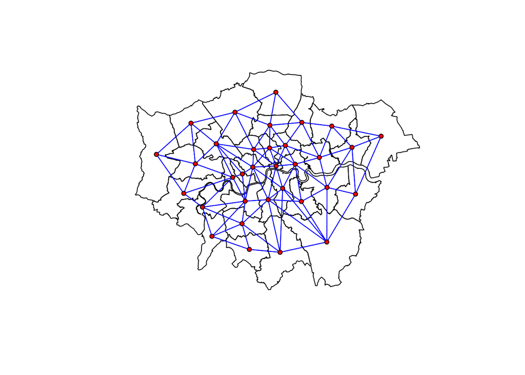

```r
plot(london.shp)
plot(london.adj, coordinates(london.shp),
     pch = ".", add = TRUE, col=4)
points(coordinates(london.shp)[,1],coordinates(london.shp)[,2],bg="red", pch=21, cex=0.75)
```

The function `nb2INLA` creates a file in the specified directory with the representation of the adjacency matrix as required by INLA for its spatial models.

```r
nb2INLA(file=paste0(mydir,"london.graph"),
        nb=london.adj)
dir() #see the new file london.graph
```

```
##  [1] "Data.xlsx"             "Examples_R_INLA.html"  "London_Borough.dbf"    "London_Borough.shp"
##  [5] "London_Borough.shx"    "london.graph"          "LondonSuicides.csv"    "SHP"
##  [9] "Tutorial_R_INLA_files" "Tutorial_R_INLA.html"  "Tutorial_R_INLA.Rmd"
```

```r
london.adj.path = paste0(mydir,"london.graph")
```

### 2 Poisson-logNormal model (with covariate only)

We implement the following Poisson regression model for the observed number of suicides in the i-th area ($y_i$):
$$y_i\sim \mbox{Poisson}(\phi_i E_i) \;\;\; i=1,...,33$$
where $\phi_i$ is the relative risk and $E_i$ the expected number of cases.

The linear predictor is defined on the logarithm scale and is given by
$$\eta_i=\log(\phi_i)=\beta_0 + \beta_1 x_{1i}$$
where $\beta_0$ is the intercept, $x_{1i}$ is the value of the covariate $x_1$ for the i-th area, $\beta_1$ is the covariate coefficient.

By default the intercept $\beta_0$ has a Gaussian prior with mean and precision equal to zero. The covariate coefficient $\beta_1$ has a Gaussian prior by default with zero mean and precision equal to 0.001.

```r
library(INLA)
formula = y ~ 1 + x1
output0 = inla(formula,
              family = "poisson",
              data = LondonSuicides,
              E = E)

summary(output0)
```

```
##
## Call:
## c("inla(formula = formula, family = \"poisson\", data = LondonSuicides, ",  "    E = E)")
##
## Time used:
##  Pre-processing    Running inla Post-processing           Total
##          1.8074          0.1441          0.0996          2.0510
##
## Fixed effects:
##                mean     sd 0.025quant 0.5quant 0.975quant    mode kld
## (Intercept) -0.1894 0.0741    -0.3357  -0.1892    -0.0446 -0.1887   0
## x1           0.0071 0.0026     0.0020   0.0071     0.0122  0.0071   0
##
## The model has no random effects
##
## The model has no hyperparameters
##
## Expected number of effective parameters(std dev): 2.009(0.00)
## Number of equivalent replicates : 16.42
##
## Marginal log-Likelihood:  -138.26
```

Note that `R-INLA` provides an estimate of the effective number of parameters (a measure of model complexity) and of the number of equivalent replicates (a measure of the number of independent observations in the data).

To account for overdispersion in the data we include an i.i.d. Gaussian random effect in the model.

### 3 Poisson-logNormal model (with covariate + iid random effect)

We implement the following Poisson regression model (see page 26 of lecture slides) for the observed number of suicides in the i-th area ($y_i$):
$$y_i\sim \mbox{Poisson}(\phi_i E_i) \;\;\; i=1,...,33$$
where $\phi_i$ is the relative risk and $E_i$ the expected number of cases.

The linear predictor is defined on the logarithm scale and is given by
$$\eta_i=\log(\phi_i)=\beta_0 + \beta_1 x_{1i} + v_{i},$$
where $\beta_0$ is the intercept, $x_{1i}$ is the value of the covariate $x_1$ for the i-th area, $\beta_1$ is the covariate coefficient. $v_i$ represents the random effect which is assumed to be normally distributed with mean equal to zero and precision $\tau_v$. The precision $\tau_{v}$ is an hyperparameter with default prior given by $\mbox{logGamma}\sim(1, 0.00005)$ (see `inla.models()$latent$iid$hyper`).

### 3.1 Run INLA

The model we want to estimate contains two fixed effects (the coefficients $\beta_0$ and $\beta_1$) and one random effect ($v_i$), which will be specified in `R-INLA` using the `f(...)` function. To deal with the random effect INLA needs an index variable (`id`) to map the effect to the areas.

```r
LondonSuicides$id = seq(1:nrow(LondonSuicides))
head(LondonSuicides)
```

```
##    GSS_CODE                 NAME  y    E       SMR    x1 id
## 1 E09000001       City of London  4  1.5 2.6948476 12.84  1
## 2 E09000002 Barking and Dagenham 34 37.5 0.9077779 34.49  2
## 3 E09000003               Barnet 68 71.6 0.9497217 21.16  3
## 4 E09000004               Bexley 57 46.6 1.2227848 16.21  4
## 5 E09000005                Brent 64 62.5 1.0235148 29.22  5
## 6 E09000006              Bromley 72 62.2 1.1577239 14.36  6
```

To run the model in `INLA` we have to specify first of all the formula

```r
formula = y ~ 1 + x1 + f(id,model="iid")
```

Then the `inla` function is run to get the output:

```r
output1 = inla(formula,
              family = "poisson",
              data = LondonSuicides,
              E = E)

summary(output1)
```

```
##
## Call:
## c("inla(formula = formula, family = \"poisson\", data = LondonSuicides, ",  "    E = E)")
##
## Time used:
##  Pre-processing    Running inla Post-processing           Total
##          1.6996          0.1656          0.0872          1.9523
##
## Fixed effects:
##                mean     sd 0.025quant 0.5quant 0.975quant    mode kld
## (Intercept) -0.1935 0.0837    -0.3616  -0.1925    -0.0309 -0.1910   0
## x1           0.0072 0.0029     0.0014   0.0072     0.0130  0.0072   0
##
## Random effects:
## Name   Model
##  id   IID model
##
## Model hyperparameters:
##                      mean       sd 0.025quant 0.5quant 0.975quant  mode
## Precision for id 11386.28 17743.39      32.57  3083.80   61841.38 47.77
##
## Expected number of effective parameters(std dev): 6.545(6.026)
## Number of equivalent replicates : 5.042
##
## Marginal log-Likelihood:  -138.75
```

```r
names(output1)
```

```
##  [1] "names.fixed"                 "summary.fixed"               "marginals.fixed"
##  [4] "summary.lincomb"             "marginals.lincomb"           "size.lincomb"
##  [7] "summary.lincomb.derived"     "marginals.lincomb.derived"   "size.lincomb.derived"
## [10] "mlik"                        "cpo"                         "po"
## [13] "waic"                        "model.random"                "summary.random"
## [16] "marginals.random"            "size.random"                 "summary.linear.predictor"
## [19] "marginals.linear.predictor"  "summary.fitted.values"       "marginals.fitted.values"
## [22] "size.linear.predictor"       "summary.hyperpar"            "marginals.hyperpar"
## [25] "internal.summary.hyperpar"   "internal.marginals.hyperpar" "offset.linear.predictor"
## [28] "model.spde2.blc"             "summary.spde2.blc"           "marginals.spde2.blc"
## [31] "size.spde2.blc"              "model.spde3.blc"             "summary.spde3.blc"
## [34] "marginals.spde3.blc"         "size.spde3.blc"              "logfile"
## [37] "misc"                        "dic"                         "mode"
## [40] "neffp"                       "joint.hyper"                 "nhyper"
## [43] "version"                     "Q"                           "graph"
## [46] "ok"                          "cpu.used"                    "all.hyper"
## [49] ".args"                       "call"                        "model.matrix"
```

Note the large posterior mean of the precision of the Gaussian random effect. This could indicate that the covariate explains the overdispersion in the data well.

### 3.2 Exploring the output: fixed effects and hyperparameters

The posterior summary statistics of the fixed effects are contained in the `summary.fixed` object:

```r
# Summary statistics of the fixed effects
output1$summary.fixed
```

```
##                    mean          sd 0.025quant     0.5quant  0.975quant         mode          kld
## (Intercept) -0.19346220 0.083730225 -0.3616186 -0.192546287 -0.03091707 -0.191038464 1.631283e-06
## x1           0.00719342 0.002933758  0.0014391  0.007180642  0.01302403  0.007163436 1.953868e-06
```

- For each fixed effect `R-INLA` reports a set of summary statistics from the posterior distribution.
- The value of the Kullback-Leibler divergence (`kld`) describes the difference between the Gaussian approximation and the Simplified Laplace Approximation (SLA) to the marginal posterior densities: small values indicate that the posterior distribution is well approximated by a Normal distribution.

The same information can be retrieved for the hyperparameters:

```r
# Summary statistics of the hyperparameter
output1$summary.hyperpar
```

```
##                      mean       sd 0.025quant 0.5quant 0.975quant     mode
## Precision for id 11386.28 17743.39   32.57167 3083.801   61841.38 47.76675
```

- For each hyperparameter the summary statistics are reported to describe the posterior distribution.
- **NB**: `R-INLA` reports results on the **precision** scale (more on this later).

### 3.3 Manipulating the marginals: fixed effects

It is also possible to extract the posterior marginal distribution of each fixed effect parameter stored in the `marginals.fixed` object.

```r
class(output1$marginals.fixed)
```

```
## [1] "list"
```

```r
names(output1$marginals.fixed)
```

```
## [1] "(Intercept)" "x1"
```

Let assume for example that we are interested in extracting and plotting the marginal posterior distribuion of $b_1$:

```r
# Extract the marginal of beta1 (from a list so we use [[...]])
beta1_post = output1$marginals.fixed[["x1"]]
class(beta1_post)
```

```
## [1] "matrix"
```

```r
head(beta1_post)
```

```
##                 x            y
## [1,] -0.022181656 8.834798e-11
## [2,] -0.016307277 1.284916e-06
## [3,] -0.012391717 1.086740e-04
## [4,] -0.010432898 7.997325e-04
## [5,] -0.010200780 1.004317e-03
## [6,] -0.007839525 9.278027e-03
```

```r
# Another function for getting summary statistics
inla.zmarginal(beta1_post)
```

```
## Mean            0.00719343
## Stdev           0.00293366
## Quantile  0.025 0.00143466
## Quantile  0.25  0.00524997
## Quantile  0.5   0.00716636
## Quantile  0.75  0.00909148
## Quantile  0.975 0.0130069
```

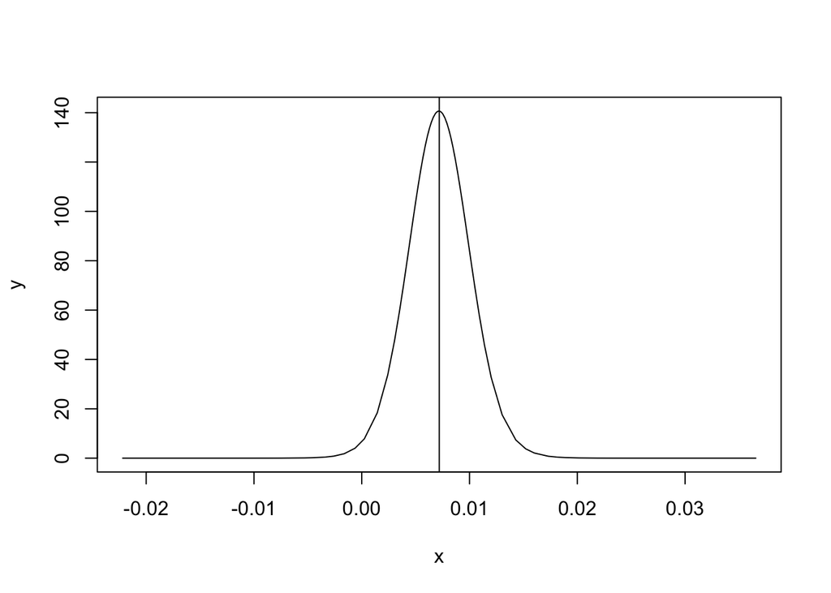

```r
# Plot the posterior marginal distribution with posterior mean
plot(beta1_post, type="l")
abline(v=output1$summary.fixed[2,"mean"])
```

It is possible to extract more information from the posterior distribution of $b_1$:

```r
# Quantile function
inla.qmarginal(0.05,beta1_post)
```

```
## [1] 0.002409872
```

```r
# Distribution function
inla.pmarginal(0.1,beta1_post)
```

```
## [1] 1
```

```r
# Density function
inla.dmarginal(0.1,beta1_post)
```

```
## [1] 0
```

```r
# Generate values from the distribution
inla.rmarginal(4,beta1_post)
```

```
## [1] 0.005035693 0.005457516 0.002990286 0.011949067
```

To estimate the effect of the covariates on the risk of suicide we compute the posterior mean of the parameter on the natural scale ($\exp(\beta_1)$). This can be obtained by means of the `inla.emarginal` function:

```r
inla.emarginal(fun=exp,marginal=output1$marginals.fixed$x1)
```

```
## [1] 1.007224
```

```r
inla.qmarginal(c(0.025,0.975),
                 inla.tmarginal(fun=exp,mar=output1$marginals.fixed$x1))
```

```
## [1] 1.001469 1.013074
```

### 3.4 Manipulating the marginal: hyperparameter

The posterior marginal distribution of the hyperparameters (in this case just the precision of the iid random effect) is stored in the `marginals.hyperpar` object (which is a list):

```r
class(output1$marginals.hyperpar)
```

```
## [1] "list"
```

```r
names(output1$marginals.hyperpar)
```

```
## [1] "Precision for id"
```

It is possible for example to plot the precision marginal posterior distribution

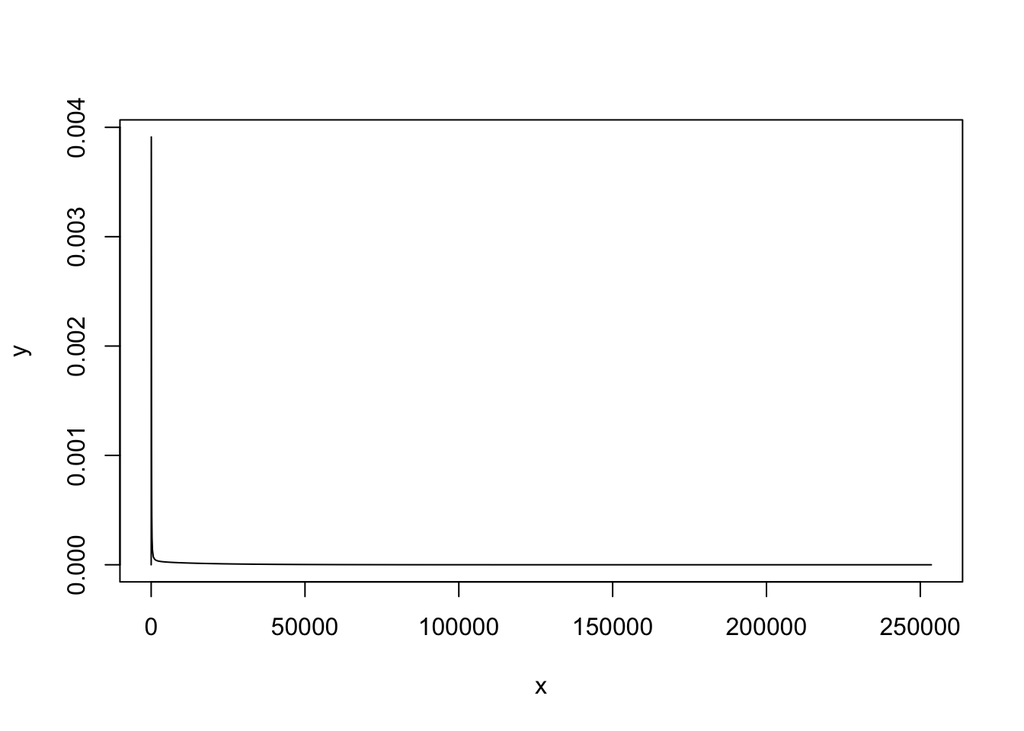

```r
prec.post = output1$marginals.hyperpar[[1]]
plot(prec.post,t="l")
```

### 3.5. Change the hyperparameter prior

Instead of the default $\mbox{logGamma}\sim(1, 0.00005)$ prior for $\log\tau_{v}$, we want for example to specify a $\mbox{logGamma}\sim(1, 0.1)$. To change the prior we use the `hyper` argument in the `f` function (see `inla.models()$latent$iid$hyper`).

In the following code we use also the option `control.compute` to compute the DIC value.

```r
formula = y ~ 1 + x1 +
  f(id,model="iid",
    hyper=list(prec=list(prior="loggamma",param=c(1,0.1))))

output2 = inla(formula,
                family = "poisson",
                data = LondonSuicides,
                E = E,
                control.compute=list(dic=TRUE))
summary(output2)
```

```
##
## Call:
## c("inla(formula = formula, family = \"poisson\", data = LondonSuicides, ",  "    E = E, control.compute = list(dic = TRUE))")
##
## Time used:
##  Pre-processing    Running inla Post-processing           Total
##          1.6785          0.1767          0.1047          1.9600
##
## Fixed effects:
##                mean     sd 0.025quant 0.5quant 0.975quant    mode kld
## (Intercept) -0.2060 0.1221    -0.4477  -0.2057     0.0337 -0.2051   0
## x1           0.0074 0.0043    -0.0011   0.0074     0.0160  0.0074   0
##
## Random effects:
## Name   Model
##  id   IID model
##
## Model hyperparameters:
##                   mean    sd 0.025quant 0.5quant 0.975quant  mode
## Precision for id 31.86 11.51      14.80    30.05      59.38 26.68
##
## Expected number of effective parameters(std dev): 20.61(2.492)
## Number of equivalent replicates : 1.601
##
## Deviance Information Criterion (DIC) ...............: 241.06
## Deviance Information Criterion (DIC, saturated) ....: 54.35
## Effective number of parameters .....................: 20.96
##
## Marginal log-Likelihood:  -135.77
## Posterior marginals for linear predictor and fitted values computed
```

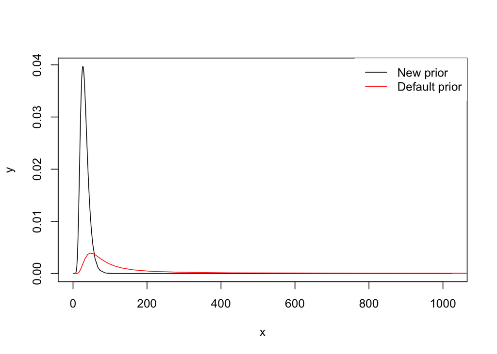

```r
prec.post2 = output2$marginals.hyperpar[[1]]

plot(prec.post2,type="l")
lines(prec.post,col=2)
legend("topright",col=1:2,lty=c(1,1),legend=c("New prior","Default prior"),box.lty=0)
```

But usually we want to make inference on more interpretable parameters, e.g. the variance or standard deviations. The function `inla.tmarginal` transforms a marginal distribution by using the desired transformation defined through `function(...){}`:

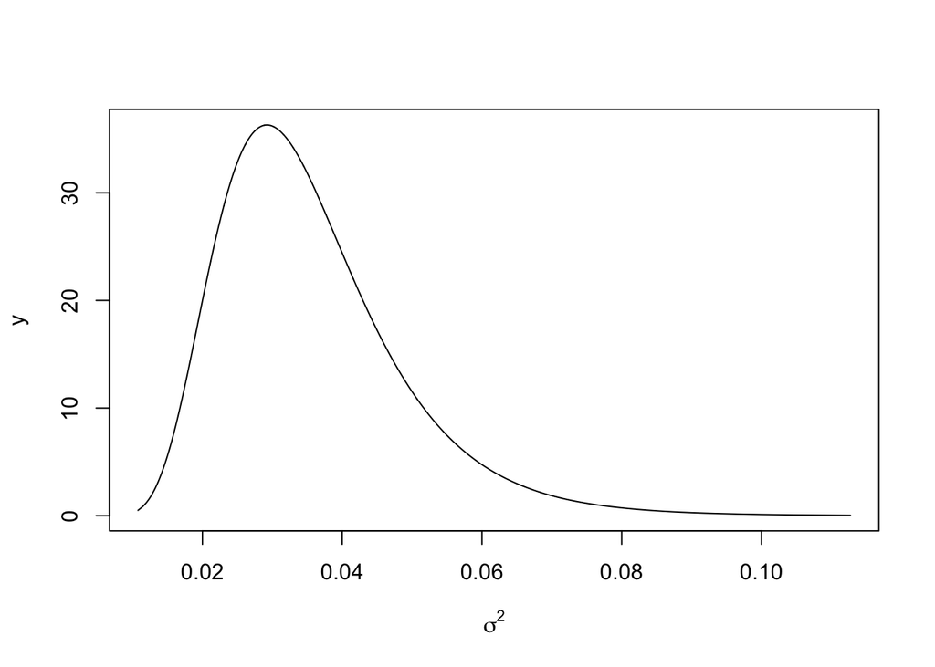

```r
# Define the marginal variance
var.post = inla.tmarginal(fun=function(x) 1/x, mar=prec.post2)
plot(var.post,type="l",xlab=expression(sigma^2))
```

As before, the function `inla.emarginal` computes the expected values of a given transformation.

```r
# Compute the posterior mean of the variance
inla.emarginal(fun=function(x) 1/x, marg=prec.post2)
```

```
## [1] 0.03558442
```

### 3.6 Explore the random effect $v$

The objects `summary.random` and `marginals.random` contain the posterior summaries and marginals of the random effect $v_i$, $i=1,...,33$.

```r
# The summary statistics for the random effects
names(output2$summary.random)
```

```
## [1] "id"
```

```r
head(output2$summary.random[[1]])
```

```
##   ID         mean        sd  0.025quant     0.5quant 0.975quant         mode          kld
## 1  1  0.089406950 0.1855924 -0.26570838  0.084874158  0.4706426  0.076278410 2.231327e-05
## 2  2 -0.080122252 0.1270878 -0.33723923 -0.077718602  0.1634663 -0.073088084 1.658365e-06
## 3  3 -0.002077095 0.1061223 -0.21383939 -0.001066596  0.2038143  0.000857712 2.974702e-07
## 4  4  0.182890373 0.1196775 -0.05034696  0.182101174  0.4200143  0.180297779 3.473602e-06
## 5  5  0.008564004 0.1072599 -0.20545703  0.009578714  0.2166711  0.011495853 2.496290e-07
## 6  6  0.169336487 0.1133045 -0.05178930  0.168687814  0.3936510  0.167247338 2.417594e-06
```

```r
#head(output2$summary.random$id) #alternatively use the dollar
dim(output2$summary.random[[1]]) #nrow = n. of areas
```

```
## [1] 33  8
```

```r
# The posterior marginals for the random effects
class(output2$marginals.random)
```

```
## [1] "list"
```

```r
names(output2$marginals.random)
```

```
## [1] "id"
```

```r
length(output2$marginals.random)
```

```
## [1] 1
```

```r
class(output2$marginals.random[["id"]])
```

```
## [1] "list"
```

```r
length(output2$marginals.random[["id"]])
```

```
## [1] 33
```

Assume that we want to compute for the FIRST area the posterior **mean** of the **exponentiated** random effect:

```r
inla.emarginal(fun=exp, marg=output2$marginals.random[["id"]][[1]])
```

```
## [1] 1.11272
```

We now want to repeat the previous computation for all the areas in order to produce a **map** of the relative risk of suicide relative to average across London. We will use `lapply` to apply the same function `inla.emarginal` to all the elements in a list:

```r
exp.v = lapply(output2$marginals.random[["id"]],
                         function(x) inla.emarginal(exp,x))
head(exp.v) #it's a list
```

```
## $index.1
## [1] 1.11272
##
## $index.2
## [1] 0.9304351
##
## $index.3
## [1] 1.003539
##
## $index.4
## [1] 1.209326
##
## $index.5
## [1] 1.014398
##
## $index.6
## [1] 1.192157
```

```r
LondonSuicides$exp.v = unlist(exp.v) #it's a vector
```

We prepare everything for the map, i.e. we update the shapefile data table with the information contained in the `LondonSuicides` dataframe:

```r
head(LondonSuicides)
```

```
##    GSS_CODE                 NAME  y    E       SMR    x1 id     exp.v
## 1 E09000001       City of London  4  1.5 2.6948476 12.84  1 1.1127203
## 2 E09000002 Barking and Dagenham 34 37.5 0.9077779 34.49  2 0.9304351
## 3 E09000003               Barnet 68 71.6 0.9497217 21.16  3 1.0035393
## 4 E09000004               Bexley 57 46.6 1.2227848 16.21  4 1.2093261
## 5 E09000005                Brent 64 62.5 1.0235148 29.22  5 1.0143975
## 6 E09000006              Bromley 72 62.2 1.1577239 14.36  6 1.1921573
```

```r
head(london.shp@data)
```

```
##                   NAME  GSS_CODE  HECTARES NONLD_AREA ONS_INNER SUB_2009 SUB_2006
## 0 Kingston upon Thames E09000021  3726.117      0.000         F     <NA>     <NA>
## 1              Croydon E09000008  8649.441      0.000         F     <NA>     <NA>
## 2              Bromley E09000006 15013.487      0.000         F     <NA>     <NA>
## 3             Hounslow E09000018  5658.541     60.755         F     <NA>     <NA>
## 4               Ealing E09000009  5554.428      0.000         F     <NA>     <NA>
## 5             Havering E09000016 11445.735    210.763         F     <NA>     <NA>
```

```r
london.shp@data = merge(london.shp@data,LondonSuicides, by="GSS_CODE")
head(london.shp@data)
```

```
##    GSS_CODE               NAME.x  HECTARES NONLD_AREA ONS_INNER SUB_2009 SUB_2006
## 1 E09000001       City of London   314.942     24.546         T     <NA>     <NA>
## 2 E09000002 Barking and Dagenham  3779.934    169.150         F     <NA>     <NA>
## 3 E09000003               Barnet  8674.837      0.000         F     <NA>     <NA>
## 4 E09000004               Bexley  6428.649    370.619         F     <NA>     <NA>
## 5 E09000005                Brent  4323.270      0.000         F     <NA>     <NA>
## 6 E09000006              Bromley 15013.487      0.000         F     <NA>     <NA>
##                 NAME.y  y    E       SMR    x1 id     exp.v
## 1       City of London  4  1.5 2.6948476 12.84  1 1.1127203
## 2 Barking and Dagenham 34 37.5 0.9077779 34.49  2 0.9304351
## 3               Barnet 68 71.6 0.9497217 21.16  3 1.0035393
## 4               Bexley 57 46.6 1.2227848 16.21  4 1.2093261
## 5                Brent 64 62.5 1.0235148 29.22  5 1.0143975
## 6              Bromley 72 62.2 1.1577239 14.36  6 1.1921573
```

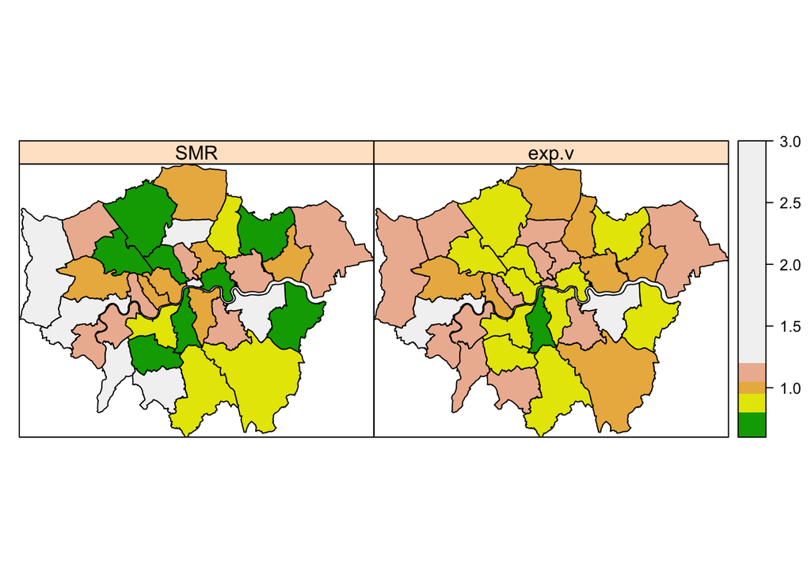

```r
# Mapping!
spplot(obj=london.shp, zcol=c("SMR", "exp.v"), at=c(0.6,0.8,0.95,1.05,1.2,3),col.regions=terrain.colors(5))
```

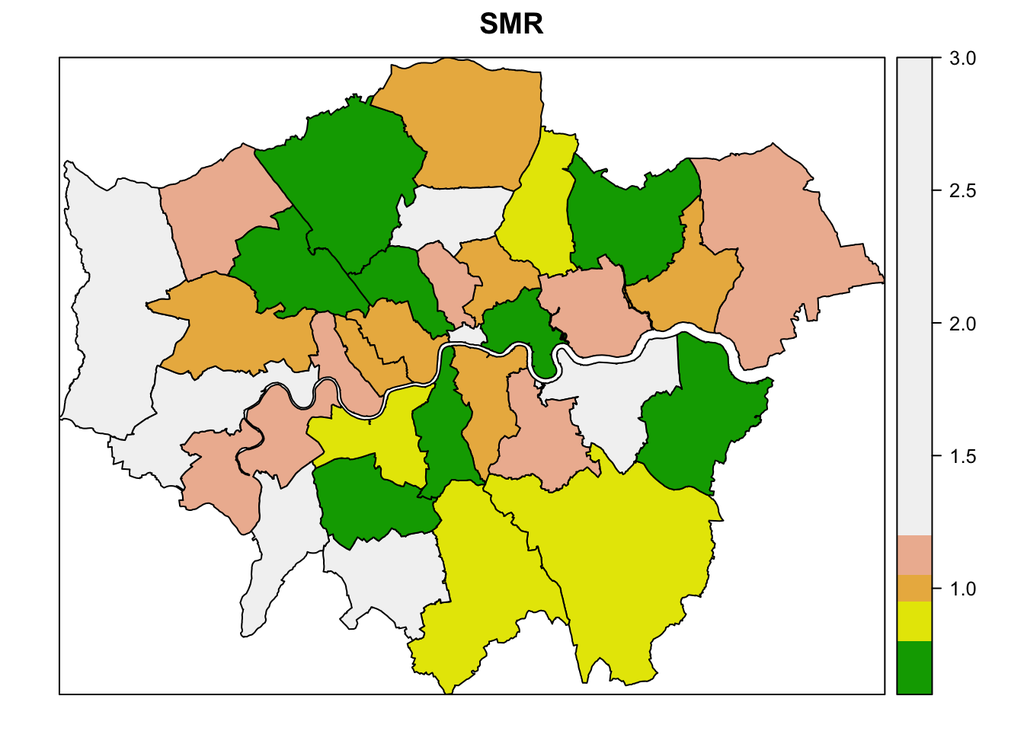

```r
spplot(obj=london.shp, zcol="SMR", main="SMR", at=c(0.6,0.8,0.95,1.05,1.2,3),col.regions=terrain.colors(5))
```

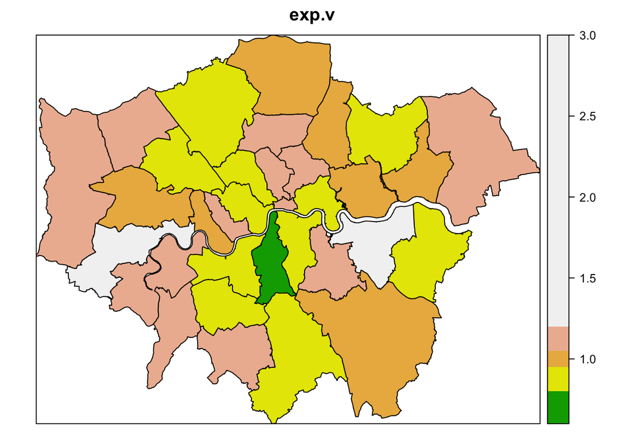

```r
spplot(obj=london.shp, zcol="exp.v", main="exp.v", at=c(0.6,0.8,0.95,1.05,1.2,3),col.regions=terrain.colors(5))
```

The following plot aims to show that, with the hierarchical model, estimated RRs (`exp.v`) are shrinked towards the mean (less variability than SMRs). We compare the SMRs with the estimated RRs.

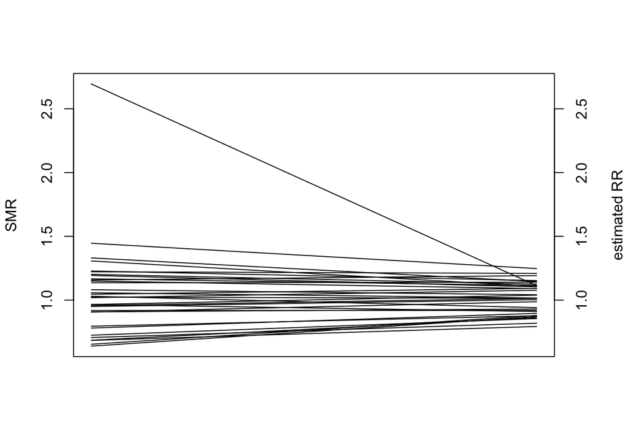

```r
op = par(mar = c(5,4,4,4) + 0.1)
plot(LondonSuicides$SMR,type="n",ylab="SMR",xaxt="n",xlab="")
for(i in 1:nrow(LondonSuicides)){
  segments(1,LondonSuicides$SMR[i],
           nrow(LondonSuicides),LondonSuicides$exp.v[i])
}
axis(side = 4)
mtext("estimated RR", side = 4, line = 3, cex = par("cex.lab"))
```

### 3.7 Compute the map of excess risk

We are now interested in mapping the excess risk defined as $p(\exp(v)>1\mid \mathbf y)$ or equivalently as $p(v>0\mid \mathbf y)$. We will use `inla.pmarginal` (distribution function) inside `lapply` to compute the required probality:

```r
threshold = 0
prob.v = lapply(output2$marginals.random[["id"]],
                          function(x) 1-inla.pmarginal(threshold,x))
range(unlist(prob.v))
```

```
## [1] 0.02353732 0.97369162
```

```r
# Add the probability vector to the dataframe
LondonSuicides$prob.v = unlist(prob.v)
head(LondonSuicides)
```

```
##    GSS_CODE                 NAME  y    E       SMR    x1 id     exp.v    prob.v
## 1 E09000001       City of London  4  1.5 2.6948476 12.84  1 1.1127203 0.6833279
## 2 E09000002 Barking and Dagenham 34 37.5 0.9077779 34.49  2 0.9304351 0.2642949
## 3 E09000003               Barnet 68 71.6 0.9497217 21.16  3 1.0035393 0.4945853
## 4 E09000004               Bexley 57 46.6 1.2227848 16.21  4 1.2093261 0.9377448
## 5 E09000005                Brent 64 62.5 1.0235148 29.22  5 1.0143975 0.5344875
## 6 E09000006              Bromley 72 62.2 1.1577239 14.36  6 1.1921573 0.9333485
```

```r
# Update the shapefile data table only with the new column
london.shp@data = merge(london.shp@data,
                        LondonSuicides[,c("GSS_CODE","prob.v")],
                        by="GSS_CODE", sort=FALSE)
head(london.shp@data)
```

```
##    GSS_CODE               NAME.x  HECTARES NONLD_AREA ONS_INNER SUB_2009 SUB_2006
## 1 E09000001       City of London   314.942     24.546         T     <NA>     <NA>
## 2 E09000002 Barking and Dagenham  3779.934    169.150         F     <NA>     <NA>
## 3 E09000003               Barnet  8674.837      0.000         F     <NA>     <NA>
## 4 E09000004               Bexley  6428.649    370.619         F     <NA>     <NA>
## 5 E09000005                Brent  4323.270      0.000         F     <NA>     <NA>
## 6 E09000006              Bromley 15013.487      0.000         F     <NA>     <NA>
##                 NAME.y  y    E       SMR    x1 id     exp.v    prob.v
## 1       City of London  4  1.5 2.6948476 12.84  1 1.1127203 0.6833279
## 2 Barking and Dagenham 34 37.5 0.9077779 34.49  2 0.9304351 0.2642949
## 3               Barnet 68 71.6 0.9497217 21.16  3 1.0035393 0.4945853
## 4               Bexley 57 46.6 1.2227848 16.21  4 1.2093261 0.9377448
## 5                Brent 64 62.5 1.0235148 29.22  5 1.0143975 0.5344875
## 6              Bromley 72 62.2 1.1577239 14.36  6 1.1921573 0.9333485
```

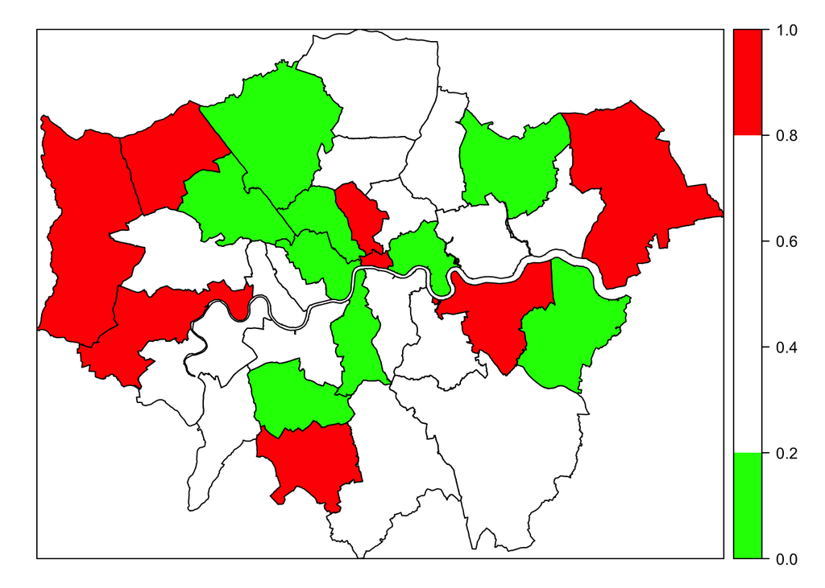

```r
# Mapping!
spplot(obj=london.shp, zcol="prob.v",main="", at=c(0,0.2,0.8,1),col.regions=c("green","white","red"))
```

## 4 Poisson-logNormal model with covariate and spatial structure

We implement the following BYM model (see slide 41 of lecture slide):
$$O_i\sim \mbox{Poisson}(\phi_i E_i) \;\;\; i=1,...,33$$
where $\phi_i$ is the relative risk.

The linear predictor is defined on the logarithm scale and is given by
$$\eta_i=\log(\phi_i)=\beta_0 + \beta_1 x_{1i}+ v_{i} + u_i$$
where $\beta_0$ is the intercept, $x_{1i}$ is the value of the covariate $x_1$ for the i-th area, $\beta_1$ is the covariate coefficient. $v_i$ represents the random effect which is assumed to be normally distributed with mean equal to zero and precision $\tau_v$. The precision $\tau_{v}$ is an hyperparameter with default prior given by $\mbox{logGamma}\sim(1, 0.00005)$ (see `inla.models()$latent$iid$hyper`).

For the spatially struttured random effect we consider the following prior distribution $\mathbf u ∼ ICAR(\mathbf W, 1/\tau_u)$ where $\mathbf W$ is the neighbourhood matrix.

For both the precision hyperparameters $\tau_v$ (`prec.unstruct`) and $\tau_v$ (`prec.spatial`) we specify a logGamma(1,0.1) prior distribution.

The new `R-INLA formula` will use the `bym` model (see `inla.doc("bym")`). The neighbourhood structure is passed through the `graph` argument.

```r
formula = y ~ 1 + x1 +
  f(id, model="bym",graph=london.adj.path,
          hyper=list(prec.unstruct=list(prior="loggamma",param=c(1,0.1)),
                     prec.spatial=list(prior="loggamma",param=c(1,0.1))))

output3 = inla(formula,
                family = "poisson",
                data = LondonSuicides,
                E = E,
                control.compute=list(dic=TRUE))
```

We explore the random effects posterior summaries:

```r
names(head(output3$summary.random))
```

```
## [1] "id"
```

```r
dim(output3$summary.random$id)
```

```
## [1] 66  8
```

```r
head(output3$summary.random$id)
```

```
##   ID         mean        sd  0.025quant     0.5quant 0.975quant         mode          kld
## 1  1  0.125643369 0.2206527 -0.29835206  0.121413846  0.5740109  0.113054158 5.761496e-05
## 2  2 -0.101818668 0.1361667 -0.37638239 -0.099483010  0.1595055 -0.094957220 6.023781e-06
## 3  3 -0.006548265 0.1100048 -0.22611863 -0.005419169  0.2065168 -0.003230102 1.455352e-06
## 4  4  0.221726172 0.1256588 -0.02657863  0.222129691  0.4674728  0.222834955 6.980476e-06
## 5  5  0.019735905 0.1116661 -0.20395003  0.021185836  0.2351433  0.024010995 1.408557e-06
## 6  6  0.188635268 0.1225544 -0.05314327  0.188904339  0.4286531  0.189386989 5.360786e-06
```

```r
tail(output3$summary.random$id)
```

```
##    ID          mean         sd 0.025quant      0.5quant 0.975quant          mode          kld
## 61 61  0.0090271220 0.09222179 -0.1714838  0.0077255555  0.1970771  0.0054533071 3.151121e-05
## 62 62  0.0135219212 0.09497554 -0.1711367  0.0117527640  0.2085073  0.0086591464 3.640570e-05
## 63 63  0.0105496325 0.09476327 -0.1750568  0.0093154276  0.2032653  0.0071328843 3.162866e-05
## 64 64 -0.0044245215 0.09395840 -0.1918650 -0.0044414376  0.1828403 -0.0044646501 2.595046e-05
## 65 65  0.0003860835 0.10463273 -0.2072044  0.0001304076  0.2090899 -0.0003735834 2.094006e-05
## 66 66  0.0038451840 0.08682311 -0.1662534  0.0026227609  0.1812640  0.0006648265 3.958505e-05
```

The latter is a dataframe formed by $2n$ rows: the first $n$ rows include information on the area specific residuals $z_i=u_i+v_i$, which are the primary interest in a disease mapping study, while the remaining present information on the spatially structured residual $u_i$ only. Recall that all these parameters are on the logarithmic scale; for the sake of interpretability it would be more convenient to transform them back to the natural scale.

The computation of the posterior mean for the random effects $z_i=v_i+u_i$ is performed using `lapply` as shown before:

```r
LondonSuicides$exp.z = unlist(lapply(output3$marginals.random$id[1:nrow(LondonSuicides)],
       function(x) inla.emarginal(exp,x)))
```

```r
LondonSuicides$prob.z = unlist(lapply(output3$marginals.random$id[1:nrow(LondonSuicides)],
                          function(x) 1-inla.pmarginal(threshold,x)))
head(LondonSuicides)
```

```
##    GSS_CODE                 NAME  y    E       SMR    x1 id     exp.v    prob.v     exp.z    prob.z
## 1 E09000001       City of London  4  1.5 2.6948476 12.84  1 1.1127203 0.6833279 1.1620877 0.7146642
## 2 E09000002 Barking and Dagenham 34 37.5 0.9077779 34.49  2 0.9304351 0.2642949 0.9115456 0.2268014
## 3 E09000003               Barnet 68 71.6 0.9497217 21.16  3 1.0035393 0.4945853 0.9994768 0.4788570
## 4 E09000004               Bexley 57 46.6 1.2227848 16.21  4 1.2093261 0.9377448 1.2581052 0.9603001
## 5 E09000005                Brent 64 62.5 1.0235148 29.22  5 1.0143975 0.5344875 1.0262759 0.5741258
## 6 E09000006              Bromley 72 62.2 1.1577239 14.36  6 1.1921573 0.9333485 1.2166914 0.9375520
```

```r
# Update the shapefile data table
london.shp@data = merge(london.shp@data,
                        LondonSuicides[,c("GSS_CODE","exp.z","prob.z")],
                        by="GSS_CODE", sort=FALSE)
head(london.shp@data)
```

```
##    GSS_CODE               NAME.x  HECTARES NONLD_AREA ONS_INNER SUB_2009 SUB_2006
## 1 E09000001       City of London   314.942     24.546         T     <NA>     <NA>
## 2 E09000002 Barking and Dagenham  3779.934    169.150         F     <NA>     <NA>
## 3 E09000003               Barnet  8674.837      0.000         F     <NA>     <NA>
## 4 E09000004               Bexley  6428.649    370.619         F     <NA>     <NA>
## 5 E09000005                Brent  4323.270      0.000         F     <NA>     <NA>
## 6 E09000006              Bromley 15013.487      0.000         F     <NA>     <NA>
##                 NAME.y  y    E       SMR    x1 id     exp.v    prob.v     exp.z    prob.z
## 1       City of London  4  1.5 2.6948476 12.84  1 1.1127203 0.6833279 1.1620877 0.7146642
## 2 Barking and Dagenham 34 37.5 0.9077779 34.49  2 0.9304351 0.2642949 0.9115456 0.2268014
## 3               Barnet 68 71.6 0.9497217 21.16  3 1.0035393 0.4945853 0.9994768 0.4788570
## 4               Bexley 57 46.6 1.2227848 16.21  4 1.2093261 0.9377448 1.2581052 0.9603001
## 5                Brent 64 62.5 1.0235148 29.22  5 1.0143975 0.5344875 1.0262759 0.5741258
## 6              Bromley 72 62.2 1.1577239 14.36  6 1.1921573 0.9333485 1.2166914 0.9375520
```

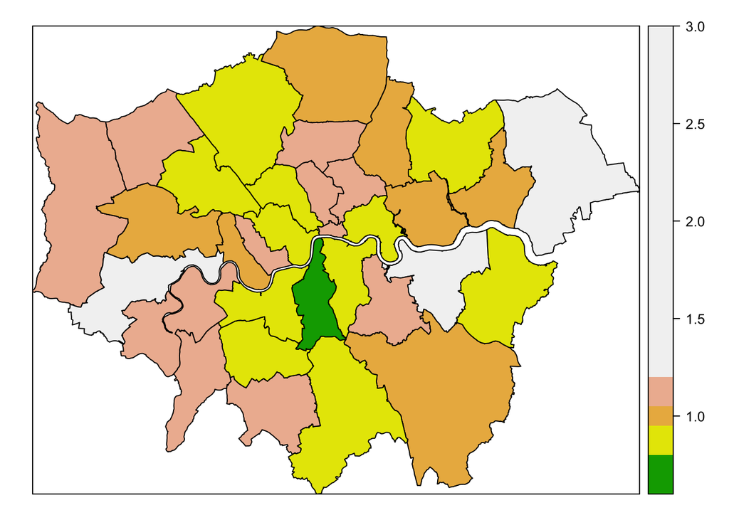

```r
# Mapping!
spplot(obj=london.shp, zcol="exp.z", at=c(0.6,0.8,0.95,1.05,1.2,3),col.regions=terrain.colors(5))
```

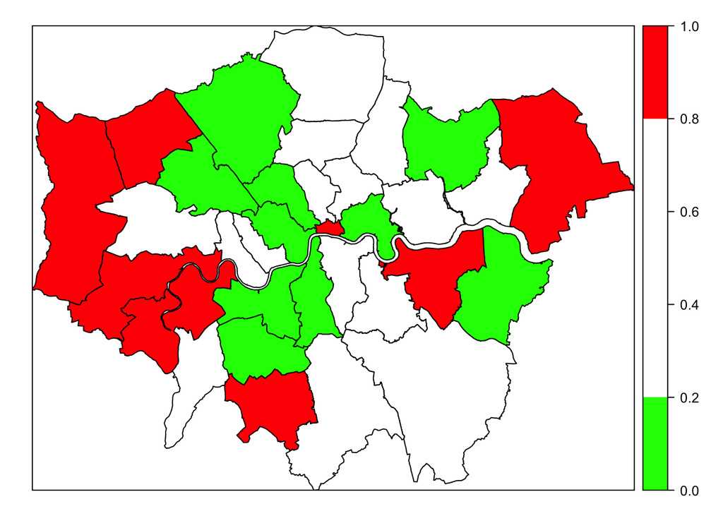

```r
spplot(obj=london.shp, zcol="prob.z",main="",at=c(0,0.2,0.8,1),col.regions=c("green","white","red"))
```

## 5 Model comparison

Let’s compare the two models (the one with $v$ only and the bym model) by DIC.

```r
output2$dic$dic #model with covariate + iid
```

```
## [1] 241.0645
```

```r
output3$dic$dic #model with covariate + bym
```

```
## [1] 242.2113
```